# Swift Keyboard

Shovit Bhari  
2020-08-14

### Introduction

- This word prediction app is a final assignment of the tenth course (Data Science Capstone) in Coursea Data Science Specialization.
- This course focuses on analyzing a large corpus of text documents to discover the structure in the data and how words are put together to build a predictive model.
- N-Gram linguistics model was used to build a smart keyboard that predicts the next word based on input of the words.

### Roadmap to the Model

- Getting and cleaning the data:  
  – All the porvided corpus was combined into one  
  – 25% of the corpus was selected for training a model
- Exploratory Data Analysis:  
  – Frequency of words and their pairs were calculated
- Modeling:  
  – Quanteda package was used to tokenize the corpus  
  – 1 to 7-gram model was built for word prediction

### Algorithm and Prediction

- To improve efficiency, word pairs that appear less than 5 times in the corpus were removed
- Katz's back-off model was used to predict the next word
- The model iterates from 7-gram to 1-gram to find matches in the last (n-1) words
- It starts from 7-gram, backs off to 6-gram if there is no prediction.
- It continues till, it back-off to 1-gram.
- When the user input is null, the most frequent word 'the' is returned when number of prediction by default is 1

### The Shiny App

Here is a link to the [application](https://shovitraj.shinyapps.io/ShinyWordPred/) which provides all the necessary instructions.

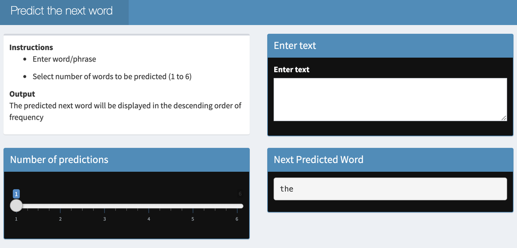

[GitHub](https://github.com/shovitraj/JHU-Capstone)

### References

- **Coursera**  
  – Data Science Specialization by JHU  
  – [Course 10: Capstone Final Project](https://www.coursera.org/learn/data-science-project/peer/EI1l4/final-project-submission)
- **Wikipedia**  
  – [Katz's back-off model](https://en.wikipedia.org/wiki/Katz%27s_back-off_model)  
  – N-gram
- **Other links**  
  – [Quanteda package](https://quanteda.io/)  
  – [NLP Stanford](https://nlp.stanford.edu/%7Ewcmac/papers/20050421-smoothing-tutorial.pdf)  
  – [N-gram models Cornell](http://www.cs.cornell.edu/courses/cs4740/2014sp/lectures/smoothing+backoff.pdf)